# Risk Factor Analysis

## Outcome Variable

**Outcome Variable:** ever_swasted

## Predictor Variables

**Intervention Variable:** fage

**Adjustment Set:**

- arm
- W_mage
- meducyrs
- feducyrs
- W_mhtcm
- W_mwtkg
- W_mbmi
- W_fhtcm
- single
- brthmon
- delta_W_mage
- delta_meducyrs
- delta_feducyrs
- delta_W_mhtcm
- delta_W_mwtkg
- delta_W_mbmi
- delta_W_fhtcm
- delta_single
- delta_brthmon

## Stratifying Variables

The analysis was stratified on these variable(s):

- agecat
- studyid
- country

## Data Summary

| agecat | studyid | country | fage | ever_swasted | n_cell | n |
| --- | --- | --- | --- | --- | --- | --- |
| 0-24 months | COHORTS | GUATEMALA | >=38 | 0 | 357 | 1285 |
| 0-24 months | COHORTS | GUATEMALA | >=38 | 1 | 25 | 1285 |
| 0-24 months | COHORTS | GUATEMALA | <32 | 0 | 554 | 1285 |
| 0-24 months | COHORTS | GUATEMALA | <32 | 1 | 47 | 1285 |
| 0-24 months | COHORTS | GUATEMALA | [32-38) | 0 | 280 | 1285 |
| 0-24 months | COHORTS | GUATEMALA | [32-38) | 1 | 22 | 1285 |
| 0-24 months | COHORTS | PHILIPPINES | >=38 | 0 | 285 | 2939 |
| 0-24 months | COHORTS | PHILIPPINES | >=38 | 1 | 43 | 2939 |
| 0-24 months | COHORTS | PHILIPPINES | <32 | 0 | 1823 | 2939 |
| 0-24 months | COHORTS | PHILIPPINES | <32 | 1 | 251 | 2939 |
| 0-24 months | COHORTS | PHILIPPINES | [32-38) | 0 | 466 | 2939 |
| 0-24 months | COHORTS | PHILIPPINES | [32-38) | 1 | 71 | 2939 |
| 0-24 months | LCNI-5 | MALAWI | >=38 | 0 | 26 | 106 |
| 0-24 months | LCNI-5 | MALAWI | >=38 | 1 | 0 | 106 |
| 0-24 months | LCNI-5 | MALAWI | <32 | 0 | 56 | 106 |
| 0-24 months | LCNI-5 | MALAWI | <32 | 1 | 0 | 106 |
| 0-24 months | LCNI-5 | MALAWI | [32-38) | 0 | 24 | 106 |
| 0-24 months | LCNI-5 | MALAWI | [32-38) | 1 | 0 | 106 |
| 0-24 months | MAL-ED | BANGLADESH | >=38 | 0 | 63 | 151 |
| 0-24 months | MAL-ED | BANGLADESH | >=38 | 1 | 6 | 151 |
| 0-24 months | MAL-ED | BANGLADESH | <32 | 0 | 28 | 151 |
| 0-24 months | MAL-ED | BANGLADESH | <32 | 1 | 2 | 151 |
| 0-24 months | MAL-ED | BANGLADESH | [32-38) | 0 | 46 | 151 |
| 0-24 months | MAL-ED | BANGLADESH | [32-38) | 1 | 6 | 151 |
| 0-24 months | MAL-ED | BRAZIL | >=38 | 0 | 30 | 79 |
| 0-24 months | MAL-ED | BRAZIL | >=38 | 1 | 0 | 79 |
| 0-24 months | MAL-ED | BRAZIL | <32 | 0 | 18 | 79 |
| 0-24 months | MAL-ED | BRAZIL | <32 | 1 | 0 | 79 |
| 0-24 months | MAL-ED | BRAZIL | [32-38) | 0 | 31 | 79 |
| 0-24 months | MAL-ED | BRAZIL | [32-38) | 1 | 0 | 79 |
| 0-24 months | MAL-ED | INDIA | >=38 | 0 | 34 | 161 |
| 0-24 months | MAL-ED | INDIA | >=38 | 1 | 2 | 161 |
| 0-24 months | MAL-ED | INDIA | <32 | 0 | 45 | 161 |
| 0-24 months | MAL-ED | INDIA | <32 | 1 | 8 | 161 |
| 0-24 months | MAL-ED | INDIA | [32-38) | 0 | 63 | 161 |
| 0-24 months | MAL-ED | INDIA | [32-38) | 1 | 9 | 161 |
| 0-24 months | MAL-ED | NEPAL | >=38 | 0 | 17 | 79 |
| 0-24 months | MAL-ED | NEPAL | >=38 | 1 | 0 | 79 |
| 0-24 months | MAL-ED | NEPAL | <32 | 0 | 13 | 79 |
| 0-24 months | MAL-ED | NEPAL | <32 | 1 | 2 | 79 |
| 0-24 months | MAL-ED | NEPAL | [32-38) | 0 | 46 | 79 |
| 0-24 months | MAL-ED | NEPAL | [32-38) | 1 | 1 | 79 |
| 0-24 months | MAL-ED | PERU | >=38 | 0 | 26 | 85 |
| 0-24 months | MAL-ED | PERU | >=38 | 1 | 1 | 85 |
| 0-24 months | MAL-ED | PERU | <32 | 0 | 28 | 85 |
| 0-24 months | MAL-ED | PERU | <32 | 1 | 1 | 85 |
| 0-24 months | MAL-ED | PERU | [32-38) | 0 | 29 | 85 |
| 0-24 months | MAL-ED | PERU | [32-38) | 1 | 0 | 85 |
| 0-24 months | MAL-ED | SOUTH AFRICA | >=38 | 0 | 62 | 90 |
| 0-24 months | MAL-ED | SOUTH AFRICA | >=38 | 1 | 3 | 90 |
| 0-24 months | MAL-ED | SOUTH AFRICA | <32 | 0 | 8 | 90 |
| 0-24 months | MAL-ED | SOUTH AFRICA | <32 | 1 | 1 | 90 |
| 0-24 months | MAL-ED | SOUTH AFRICA | [32-38) | 0 | 14 | 90 |
| 0-24 months | MAL-ED | SOUTH AFRICA | [32-38) | 1 | 2 | 90 |
| 0-24 months | MAL-ED | TANZANIA, UNITED REPUBLIC OF | >=38 | 0 | 48 | 100 |
| 0-24 months | MAL-ED | TANZANIA, UNITED REPUBLIC OF | >=38 | 1 | 0 | 100 |
| 0-24 months | MAL-ED | TANZANIA, UNITED REPUBLIC OF | <32 | 0 | 14 | 100 |
| 0-24 months | MAL-ED | TANZANIA, UNITED REPUBLIC OF | <32 | 1 | 1 | 100 |
| 0-24 months | MAL-ED | TANZANIA, UNITED REPUBLIC OF | [32-38) | 0 | 34 | 100 |
| 0-24 months | MAL-ED | TANZANIA, UNITED REPUBLIC OF | [32-38) | 1 | 3 | 100 |
| 0-24 months | PROBIT | BELARUS | >=38 | 0 | 692 | 16278 |
| 0-24 months | PROBIT | BELARUS | >=38 | 1 | 52 | 16278 |
| 0-24 months | PROBIT | BELARUS | <32 | 0 | 12012 | 16278 |
| 0-24 months | PROBIT | BELARUS | <32 | 1 | 1047 | 16278 |
| 0-24 months | PROBIT | BELARUS | [32-38) | 0 | 2304 | 16278 |
| 0-24 months | PROBIT | BELARUS | [32-38) | 1 | 171 | 16278 |
| 0-24 months | SAS-CompFeed | INDIA | >=38 | 0 | 32 | 1510 |
| 0-24 months | SAS-CompFeed | INDIA | >=38 | 1 | 17 | 1510 |
| 0-24 months | SAS-CompFeed | INDIA | <32 | 0 | 1086 | 1510 |
| 0-24 months | SAS-CompFeed | INDIA | <32 | 1 | 178 | 1510 |
| 0-24 months | SAS-CompFeed | INDIA | [32-38) | 0 | 169 | 1510 |
| 0-24 months | SAS-CompFeed | INDIA | [32-38) | 1 | 28 | 1510 |
| 0-24 months | SAS-FoodSuppl | INDIA | >=38 | 0 | 31 | 418 |
| 0-24 months | SAS-FoodSuppl | INDIA | >=38 | 1 | 13 | 418 |
| 0-24 months | SAS-FoodSuppl | INDIA | <32 | 0 | 247 | 418 |
| 0-24 months | SAS-FoodSuppl | INDIA | <32 | 1 | 42 | 418 |
| 0-24 months | SAS-FoodSuppl | INDIA | [32-38) | 0 | 69 | 418 |
| 0-24 months | SAS-FoodSuppl | INDIA | [32-38) | 1 | 16 | 418 |

The following strata were considered:

- agecat: 0-24 months, studyid: COHORTS, country: GUATEMALA
- agecat: 0-24 months, studyid: COHORTS, country: PHILIPPINES
- agecat: 0-24 months, studyid: LCNI-5, country: MALAWI
- agecat: 0-24 months, studyid: MAL-ED, country: BANGLADESH
- agecat: 0-24 months, studyid: MAL-ED, country: BRAZIL
- agecat: 0-24 months, studyid: MAL-ED, country: INDIA
- agecat: 0-24 months, studyid: MAL-ED, country: NEPAL
- agecat: 0-24 months, studyid: MAL-ED, country: PERU
- agecat: 0-24 months, studyid: MAL-ED, country: SOUTH AFRICA
- agecat: 0-24 months, studyid: MAL-ED, country: TANZANIA, UNITED REPUBLIC OF
- agecat: 0-24 months, studyid: PROBIT, country: BELARUS
- agecat: 0-24 months, studyid: SAS-CompFeed, country: INDIA
- agecat: 0-24 months, studyid: SAS-FoodSuppl, country: INDIA

### Dropped Strata

Some strata were dropped due to rare outcomes:

- agecat: 0-24 months, studyid: LCNI-5, country: MALAWI
- agecat: 0-24 months, studyid: MAL-ED, country: BANGLADESH
- agecat: 0-24 months, studyid: MAL-ED, country: BRAZIL
- agecat: 0-24 months, studyid: MAL-ED, country: INDIA
- agecat: 0-24 months, studyid: MAL-ED, country: NEPAL
- agecat: 0-24 months, studyid: MAL-ED, country: PERU
- agecat: 0-24 months, studyid: MAL-ED, country: SOUTH AFRICA
- agecat: 0-24 months, studyid: MAL-ED, country: TANZANIA, UNITED REPUBLIC OF

## Methods Detail

We're interested in the causal parameters $E[Y_a]$ for all values of $a \in \mathcal{A}$. These parameters represent the mean outcome if, possibly contrary to fact, we intervened to set all units to have $A=a$. Under the randomization and positivity assumptions, these are identified by the statistical parameters $\psi_a=E_W[E_{Y|A,W}(Y|A=a,W)]$. In addition, we're interested in the mean of $Y$, $E[Y]$ under no intervention (the observed mean). We will estimate these parameters by using SuperLearner to fit the relevant likelihood factors -- $E_{Y|A,W}(Y|A=a,W)$ and $p(A=a|W)$, and then updating our likelihood fit using a joint TMLE.

For unadjusted analyses ($W=\{\}$), initial likelihoods were estimated using Lrnr_glm to estimate the simple $E(Y|A)$ and Lrnr_mean to estimate $p(A)$. For adjusted analyses, a small library containing Lrnr_glmnet, Lrnr_xgboost, and Lrnr_mean was used.

Having estimated these parameters, we will then use the delta method to estimate relative risks and attributable risks relative to a prespecified baseline level of $A$.

# Results Detail

## Results Plots

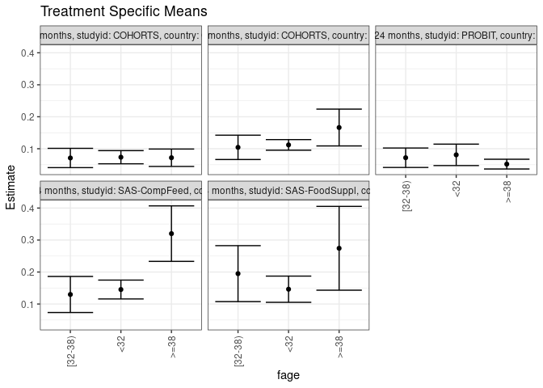

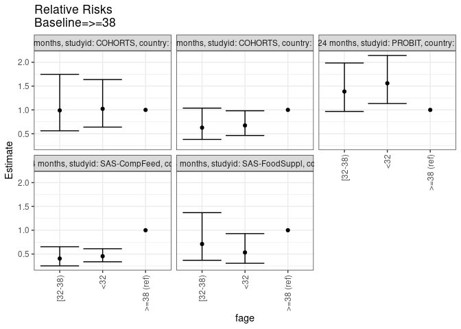

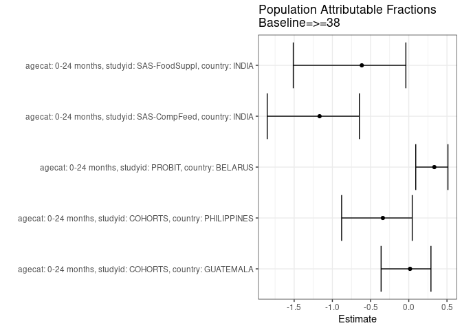

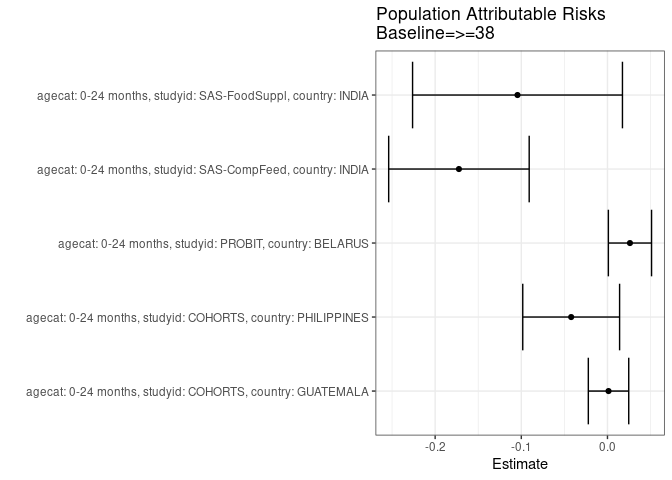

## Results Table

### Parameter: TSM

| agecat | studyid | country | intervention_level | baseline_level | estimate | ci_lower | ci_upper |
| --- | --- | --- | --- | --- | --- | --- | --- |
| 0-24 months | COHORTS | GUATEMALA | >=38 | NA | 0.0719209 | 0.0447209 | 0.0991209 |
| 0-24 months | COHORTS | GUATEMALA | <32 | NA | 0.0735482 | 0.0529680 | 0.0941285 |
| 0-24 months | COHORTS | GUATEMALA | [32-38) | NA | 0.0711642 | 0.0409999 | 0.1013286 |
| 0-24 months | COHORTS | PHILIPPINES | >=38 | NA | 0.1663139 | 0.1087580 | 0.2238699 |
| 0-24 months | COHORTS | PHILIPPINES | <32 | NA | 0.1120496 | 0.0954591 | 0.1286400 |
| 0-24 months | COHORTS | PHILIPPINES | [32-38) | NA | 0.1043791 | 0.0663492 | 0.1424090 |
| 0-24 months | PROBIT | BELARUS | >=38 | NA | 0.0519175 | 0.0366731 | 0.0671619 |
| 0-24 months | PROBIT | BELARUS | <32 | NA | 0.0809512 | 0.0474207 | 0.1144817 |
| 0-24 months | PROBIT | BELARUS | [32-38) | NA | 0.0719395 | 0.0415280 | 0.1023509 |
| 0-24 months | SAS-CompFeed | INDIA | >=38 | NA | 0.3200684 | 0.2333236 | 0.4068131 |
| 0-24 months | SAS-CompFeed | INDIA | <32 | NA | 0.1453282 | 0.1158332 | 0.1748233 |
| 0-24 months | SAS-CompFeed | INDIA | [32-38) | NA | 0.1297975 | 0.0734113 | 0.1861836 |
| 0-24 months | SAS-FoodSuppl | INDIA | >=38 | NA | 0.2742582 | 0.1431920 | 0.4053245 |
| 0-24 months | SAS-FoodSuppl | INDIA | <32 | NA | 0.1462855 | 0.1053009 | 0.1872701 |
| 0-24 months | SAS-FoodSuppl | INDIA | [32-38) | NA | 0.1949559 | 0.1074875 | 0.2824243 |

### Parameter: E(Y)

| agecat | studyid | country | intervention_level | baseline_level | estimate | ci_lower | ci_upper |
| --- | --- | --- | --- | --- | --- | --- | --- |
| 0-24 months | COHORTS | GUATEMALA | NA | NA | 0.0731518 | 0.0589094 | 0.0873941 |
| 0-24 months | COHORTS | PHILIPPINES | NA | NA | 0.1241919 | 0.1122665 | 0.1361173 |
| 0-24 months | PROBIT | BELARUS | NA | NA | 0.0780194 | 0.0455878 | 0.1104510 |
| 0-24 months | SAS-CompFeed | INDIA | NA | NA | 0.1476821 | 0.1188009 | 0.1765633 |
| 0-24 months | SAS-FoodSuppl | INDIA | NA | NA | 0.1698565 | 0.1338154 | 0.2058975 |

### Parameter: RR

| agecat | studyid | country | intervention_level | baseline_level | estimate | ci_lower | ci_upper |
| --- | --- | --- | --- | --- | --- | --- | --- |
| 0-24 months | COHORTS | GUATEMALA | >=38 | >=38 | 1.0000000 | 1.0000000 | 1.0000000 |
| 0-24 months | COHORTS | GUATEMALA | <32 | >=38 | 1.0226266 | 0.6387513 | 1.6372025 |
| 0-24 months | COHORTS | GUATEMALA | [32-38) | >=38 | 0.9894790 | 0.5606410 | 1.7463382 |
| 0-24 months | COHORTS | PHILIPPINES | >=38 | >=38 | 1.0000000 | 1.0000000 | 1.0000000 |
| 0-24 months | COHORTS | PHILIPPINES | <32 | >=38 | 0.6737232 | 0.4624117 | 0.9815993 |
| 0-24 months | COHORTS | PHILIPPINES | [32-38) | >=38 | 0.6276026 | 0.3796506 | 1.0374937 |
| 0-24 months | PROBIT | BELARUS | >=38 | >=38 | 1.0000000 | 1.0000000 | 1.0000000 |
| 0-24 months | PROBIT | BELARUS | <32 | >=38 | 1.5592267 | 1.1340166 | 2.1438734 |
| 0-24 months | PROBIT | BELARUS | [32-38) | >=38 | 1.3856487 | 0.9673197 | 1.9848889 |
| 0-24 months | SAS-CompFeed | INDIA | >=38 | >=38 | 1.0000000 | 1.0000000 | 1.0000000 |
| 0-24 months | SAS-CompFeed | INDIA | <32 | >=38 | 0.4540537 | 0.3373090 | 0.6112044 |
| 0-24 months | SAS-CompFeed | INDIA | [32-38) | >=38 | 0.4055304 | 0.2515152 | 0.6538567 |
| 0-24 months | SAS-FoodSuppl | INDIA | >=38 | >=38 | 1.0000000 | 1.0000000 | 1.0000000 |
| 0-24 months | SAS-FoodSuppl | INDIA | <32 | >=38 | 0.5333860 | 0.3061436 | 0.9293046 |
| 0-24 months | SAS-FoodSuppl | INDIA | [32-38) | >=38 | 0.7108480 | 0.3690588 | 1.3691717 |

### Parameter: PAR

| agecat | studyid | country | intervention_level | baseline_level | estimate | ci_lower | ci_upper |
| --- | --- | --- | --- | --- | --- | --- | --- |
| 0-24 months | COHORTS | GUATEMALA | >=38 | NA | 0.0012308 | -0.0222163 | 0.0246780 |
| 0-24 months | COHORTS | PHILIPPINES | >=38 | NA | -0.0421220 | -0.0983231 | 0.0140790 |
| 0-24 months | PROBIT | BELARUS | >=38 | NA | 0.0261019 | 0.0010407 | 0.0511631 |
| 0-24 months | SAS-CompFeed | INDIA | >=38 | NA | -0.1723863 | -0.2539270 | -0.0908455 |
| 0-24 months | SAS-FoodSuppl | INDIA | >=38 | NA | -0.1044018 | -0.2261971 | 0.0173935 |

### Parameter: PAF

| agecat | studyid | country | intervention_level | baseline_level | estimate | ci_lower | ci_upper |
| --- | --- | --- | --- | --- | --- | --- | --- |
| 0-24 months | COHORTS | GUATEMALA | >=38 | NA | 0.0168257 | -0.3620590 | 0.2903159 |
| 0-24 months | COHORTS | PHILIPPINES | >=38 | NA | -0.3391688 | -0.8787922 | 0.0454649 |
| 0-24 months | PROBIT | BELARUS | >=38 | NA | 0.3345563 | 0.0913645 | 0.5126590 |
| 0-24 months | SAS-CompFeed | INDIA | >=38 | NA | -1.1672792 | -1.8527583 | -0.6465114 |
| 0-24 months | SAS-FoodSuppl | INDIA | >=38 | NA | -0.6146471 | -1.5116218 | -0.0380087 |